# “Metabolic and Stress Physiology of Cottonmouth Snakes, *Agkistrodon piscivorous*”

Molly Richard

## **Introduction**

The analysis of glucocorticoid hormones has become an increasingly popular technique for measuring stress levels of animals facing environmental challenges. Glucocorticoids (GCs) are stress hormones released by the hypothalamus–pituitary–adrenal axis when a stressor starts a chain reaction in the body signaling the release of GCs to cope with the stressful situation. These stressors can originate from temperature changes, food shortages, reproductive strategies, social status or anthropogenic disturbances that require an alteration in physiology or behavior to meet basic physiological requirements. There are several hormones (e.g., cortisol, corticosterone) that are excreted during stressful events to aid in mediation.Behavioral responses have been shown to impact escape or avoidance efforts and reproductive success. Physiological responses can affect locomotor performance, immunity levels, reproductive physiology, and metabolism to provide immediate energy to overcome challenges.GCs play an important role in managing metabolism throughout the fluctuating baseline levels (homeostasis) and increased stressed levels (allostasis) by regulating glucose levels to meet energic needs of the various physiological processes.

## **Objectives**

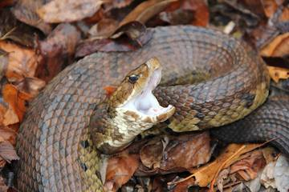

Fig 1. Cottonmouth displaying threat response behavior

We proposed to assess the relationship between metabolism and corticosterone (CORT) levels by comparing baseline and stress-induced changes in CORT with standard metabolic rates (SMR) in cottonmouth snakes, *Agkistrodon piscivorous*.

## **Methods**

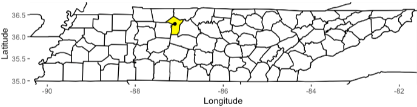

Fig 2. State map displaying location of field site at Bicentennial Trail Wetland, Cheatham Co., TN

[interactive chart not shown]

Fig 3. Interactive map displaying capture locations with in Bicentennial Trail Wetland

## **Preliminary Results**

### Standard Metabolic Rate

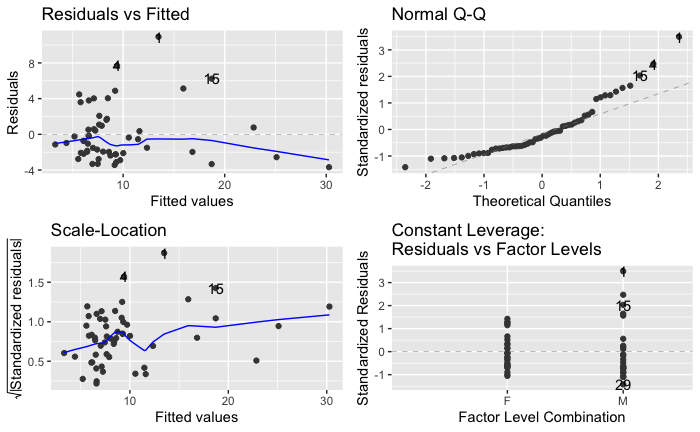

Fig 4. Autoplot for checking linear model assumptions for the effects of mass and sex on oxygen consumption.

```
Analysis of Variance Table

Response: SMR_Hour
          Df  Sum Sq Mean Sq  F value    Pr(>F)
Mass_g     1 1406.26 1406.26 137.9023 4.077e-16 ***
Sex        1   37.86   37.86   3.7124   0.05959 .
Residuals 51  520.07   10.20
---
Signif. codes:  0 ‘***’ 0.001 ‘**’ 0.01 ‘*’ 0.05 ‘.’ 0.1 ‘ ’ 1

Call:
lm(formula = SMR_Hour ~ Mass_g + Sex, data = data)

Residuals:
    Min      1Q  Median      3Q     Max
-3.6800 -2.1626 -0.8567  1.0566 10.9259

Coefficients:
            Estimate Std. Error t value Pr(>|t|)
(Intercept) 2.038471   0.773695   2.635   0.0111 *
Mass_g      0.017220   0.001685  10.219 6.12e-14 ***
SexM        1.801133   0.934798   1.927   0.0596 .
---
Signif. codes:  0 ‘***’ 0.001 ‘**’ 0.01 ‘*’ 0.05 ‘.’ 0.1 ‘ ’ 1

Residual standard error: 3.193 on 51 degrees of freedom
Multiple R-squared:  0.7352,    Adjusted R-squared:  0.7248
F-statistic: 70.81 on 2 and 51 DF,  p-value: 1.921e-15
```

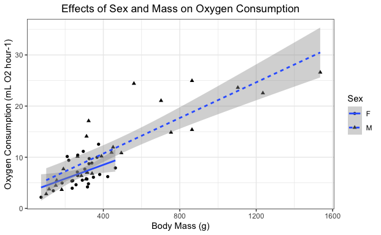

Fig 5. SMR (mL O<sub>2</sub> hour <sup>-1</sup>) as a function of body mass (p<0.05) and sex (p = 0.0596, R<sup>2</sup> = 0.7248).

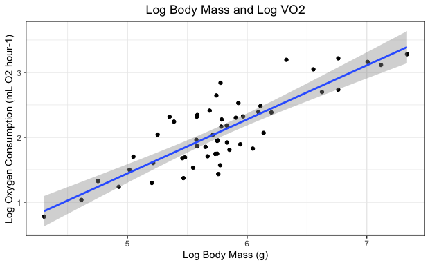

Fig 6. Log of SMR (mL O<sub>2</sub> hour -1) as a function of the log of body mass (g).

### Mass Adjusted VO<sub>2</sub>

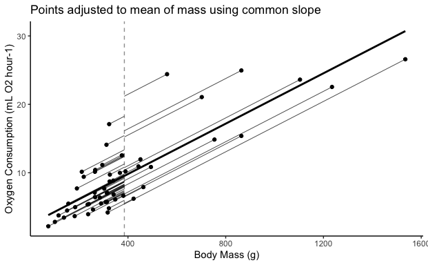

Fig 7. Mass adjusted VO<sub>2</sub> of individuals based on mean body mass (dashed line, 385.24g) using a common slope (thick line, 0.0184).

## **Summary of Results**

Next analysis would be to run global general linear models for a poisson distribution: the response variable being CORT level(s), and the effect variables being Mass Adjusted VO<sub>2</sub>, sex, date, time of day, collection time, base temp, stress temp, and the time between samples.

## **Discussion**

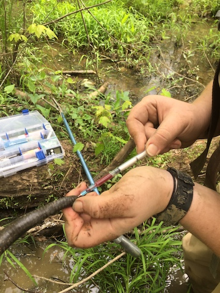

Fig 8. Blood draw from the caudel vien of a cottonmouth snake

The boardline significant p-values for sex effects could be due to the extreme sexual body size dimorphism of the species: the largest male weighing 1535g and the largest female weighing 463g. By using the Mass Adjusted VO<sub>2</sub>, we are able to remove the effects of body mass from the proposed analysis of metablic rate and CORT levels. Additional covariates could potential be affecting CORT levels and will be included in future analyses. Extensive research has assessed seasonal influences on stress levels in both ecto- and endo-therms and will be taken into account through date of capture and the time of day as covariates.  
Much of what is known about the relationship between GCs and metabolism is based on theory and applied applications of glucocorticoids. This techniques involves either the external application of CORT or the implantation of an internal CORT pellet to assess the physiological effects of increased CORT levels. The use of these methods however do not take into account the individual variations in CORT response. Jimeno et al found an association between natural produced CORT and metablic rate in zebra finches using similar methods to this study. Assessing the intra-individual variation in this manner can provide additional insights into a more informative relationship between hormonal responses to stressful environments and their energic requirements.

## **References**

https://github.com/MollyARichard/AgPi-SMR-Prelim/blob/master/README.md